Question de recherche : entre 1961 et 2021, comment l’écart de revenu d’emploi et de statut socioprofessionnel entre francophones et anglophones de langue maternelle au Québec a-t-il évolué, et à partir de quel recensement cet écart s’est-il inversé, si tant est qu’il l’ait fait ?

# 1 Introduction

# 2 Méthode

Le repérage des sources suit la méthode du *snowballing* (Jalali et Wohlin 2012) : à partir d’un ensemble de départ de onze publications récentes couvrant cinq communautés savantes (économie du langage, histoire économique, sociologie de la stratification, aménagement linguistique, littérature grise sur le recensement de 2021), on dépouille les listes de références (*backward*) et les publications citantes (*forward*), puis on répète l’opération avec chaque texte retenu jusqu’à saturation. Quatre rondes, dont une consacrée aux travaux citant l’échelle professionnelle de Blishen (1958) et *The Vertical Mosaic* de Porter (1965), ont produit un corpus de 103 publications et 101 bibliographies dépouillées. Une publication est retenue si elle compare explicitement francophones et anglophones au Québec (critère obligatoire) et si elle mesure le revenu d’emploi ou le statut socioprofessionnel, couvre un recensement de 1961 à 2021 ou propose une explication (au moins trois points sur six) ; les travaux de contexte sont conservés dans la grille sans être classés.

Chaque publication reçoit un indice de pertinence de 0 à 1, moyenne à poids égaux de trois indicateurs normalisés (min-max) : le nombre de citations Google Scholar (en logarithme ; relevé avec un script Python fondé sur la bibliothèque *scholarly*, sinon compte Consensus ramené à l’échelle de Google Scholar), l’année de publication et la récurrence, soit le nombre de bibliographies du corpus qui citent la publication. La figure 1 classe les trente publications incluses les mieux notées ; la figure 2 montre comment elles se citent, la disposition par forces rapprochant les textes qui se citent mutuellement. Les fondateurs vers lesquels convergent les flèches (Commission royale d’enquête sur le bilinguisme et le biculturalisme 1969; Raynauld et al. 1966; Vaillancourt 1980) s’y distinguent des synthèses récentes qui citent sans être encore citées. La grille, les bibliographies, les scripts Python (grille, score, réseau, export Zotero) et le code R des figures sont dans le dépôt GitHub `stratification_qc` ; les bibliographies ayant été reconstituées sans les PDF, les récurrences sont des bornes inférieures.

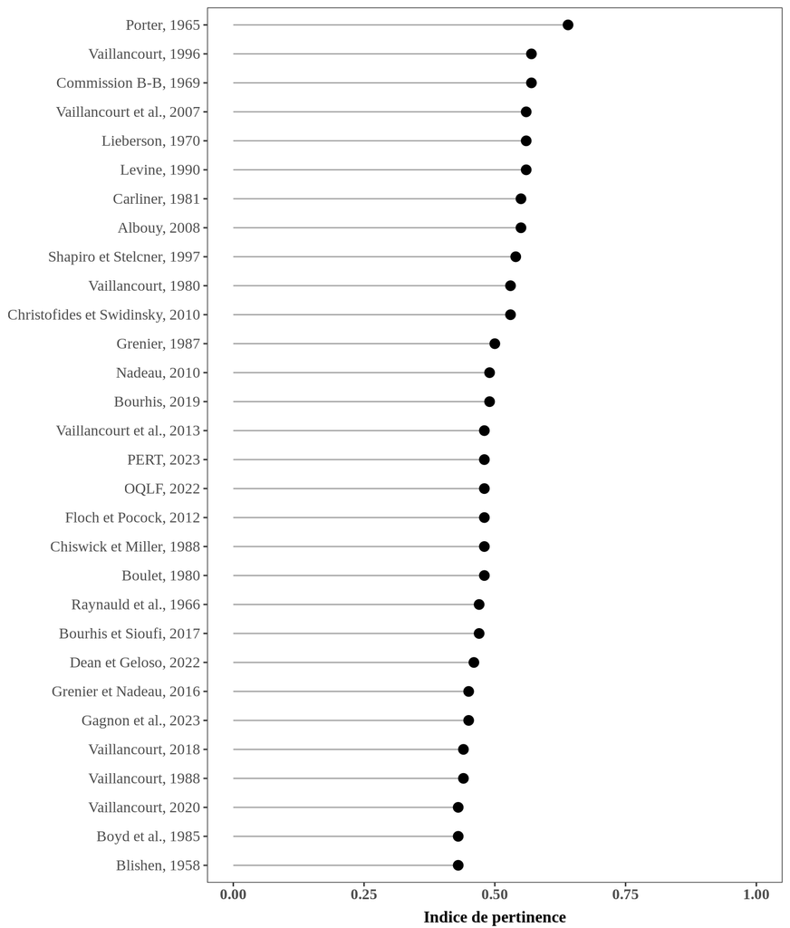

Les trente lectures les plus pertinentes (indice = moyenne à poids égaux des citations, de l’année et de la récurrence dans les bibliographies du corpus).

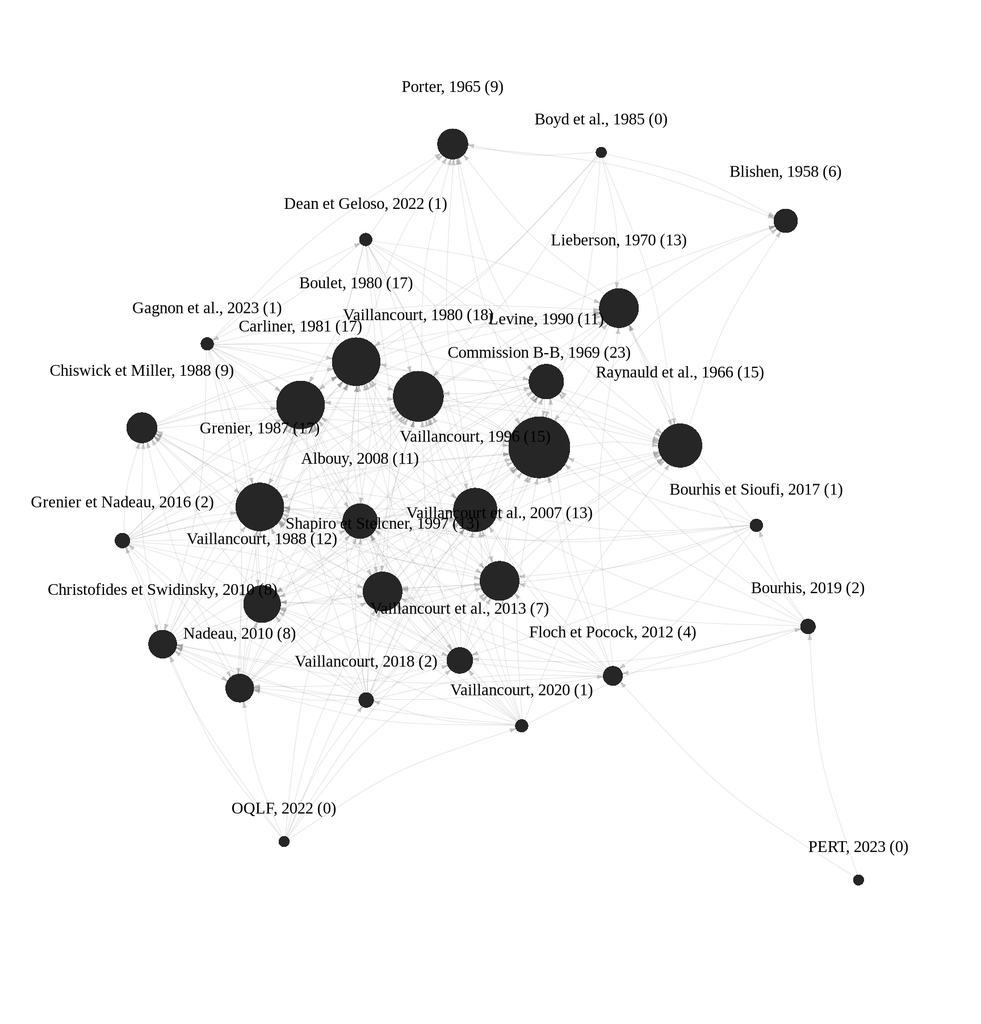

Réseau de citations entre les trente lectures (flèche : « cite » ; taille du point : citations reçues des autres lectures ; disposition par forces).

# 3 Revue de littérature

# Bibliographie

Albouy, David. 2008. « The wage gap between Francophones and Anglophones: a Canadian perspective, 1970-2000 ». *Canadian Journal of Economics* 41 (4): 1211‑38. https://doi.org/10.1111/j.1540-5982.2008.00501.x.

Blishen, Bernard R. 1958. « The construction and use of an occupational class scale ». *Canadian Journal of Economics and Political Science* 24 (4): 519‑31. https://doi.org/10.2307/139088.

Boulet, Jac-André. 1980. *Language and Earnings in Montreal / La langue et le revenu du travail à Montréal*. Ottawa : Conseil économique du Canada.

Bourhis, Richard Y. 2019. « Evaluating the impact of Bill 101 on the English-speaking communities of Quebec ». *Language Problems and Language Planning* 43 (2). https://doi.org/10.1075/lplp.00042.bou.

Bourhis, Richard Y., et Rana Sioufi. 2017. « Assessing forty years of language planning on the vitality of the francophone and anglophone communities of Quebec ». *Multilingua* 36 (5): 627‑61. https://doi.org/10.1515/multi-2017-3048.

Boyd, Monica, John Goyder, Frank E. Jones, Hugh A. McRoberts, Peter C. Pineo, et John Porter. 1985. *Ascription and Achievement: Studies in Mobility and Status Attainment in Canada*. Ottawa : Carleton University Press.

Carliner, Geoffrey. 1981. « Wage differences by language group and the market for language skills in Canada ». *Journal of Human Resources* 16 (3): 384‑99. https://doi.org/10.2307/145627.

Chiswick, Barry R., et Paul W. Miller. 1988. « Earnings in Canada: The roles of immigrant generation, French ethnicity, and language ». *Research in Population Economics* 6: 183‑228. https://doi.org/10.4324/9780203963159-26.

Christofides, Louis N., et Robert Swidinsky. 2010. « The economic returns to the knowledge and use of a second official language: English in Quebec and French in the rest-of-Canada ». *Canadian Public Policy / Analyse de politiques* 36 (2): 137‑58. https://doi.org/10.3138/cpp.36.2.137.

Commission royale d’enquête sur le bilinguisme et le biculturalisme. 1969. *Rapport de la Commission royale d’enquête sur le bilinguisme et le biculturalisme, Livre III : Le monde du travail*. Ottawa : Imprimeur de la Reine.

Dean, Joshua, et Vincent Geloso. 2022. « The linguistic wage gap in Quebec, 1901 to 1951 ». *Cliometrica*, publication en ligne anticipée. https://doi.org/10.1007/s11698-021-00236-3.

Floch, William, et Joanne Pocock. 2012. « The socio-economic status of English-speaking Quebec: Those who left and those who stayed ». In *In R. Y. Bourhis (dir.), Decline and Prospects of the English-Speaking Communities of Quebec, Ottawa : Patrimoine canadien, 127-173*.

Gagnon, Julien, Vincent Geloso, et Maripier Isabelle. 2023. « The incubated revolution: Education, cohort effects, and the linguistic wage gap in Quebec during the 20th century ». *Journal of Economic Behavior & Organization*, publication en ligne anticipée. https://doi.org/10.1016/j.jebo.2022.12.017.

Grenier, Gilles. 1987. « Earnings by language group in Quebec in 1980 and emigration from Quebec between 1976 and 1981 ». *Canadian Journal of Economics* 20 (4): 774‑91. https://doi.org/10.2307/135415.

Grenier, Gilles, et Serge Nadeau. 2016. « English as the lingua franca and the economic value of other languages: The case of the language of work in the Montreal labor market ». In *In M. Gazzola et B.-A. Wickström (dir.), The Economics of Language Policy, Cambridge (MA) : MIT Press, 267-312*.

Jalali, Samireh, et Claes Wohlin. 2012. « Systematic literature studies: Database searches vs. backward snowballing ». *Proceedings of the ACM-IEEE International Symposium on Empirical Software Engineering and Measurement (ESEM ’12)* (Lund), 29‑38. https://doi.org/10.1145/2372251.2372257.

Levine, Marc V. 1990. *The Reconquest of Montreal: Language Policy and Social Change in a Bilingual City*. Philadelphia : Temple University Press.

Lieberson, Stanley. 1970. *Language and Ethnic Relations in Canada*. New York : John Wiley & Sons.

Nadeau, Serge. 2010. « Another look at the Francophone wage gap in Canada: Public and private sectors, Quebec and outside Quebec ». *Canadian Public Policy / Analyse de politiques* 36 (2): 159‑79. https://doi.org/10.3138/cpp.36.2.159.

Office québécois de la langue française. 2022. *Portrait du revenu d’emploi au Québec en 2015 selon les langues utilisées au travail*. Québec : OQLF (étude fondée sur le recensement de 2016). https://www.oqlf.gouv.qc.ca/ressources/sociolinguistique/2022/2022_etude_revenu-emploi-selon-langues-utilisees-travail.pdf.

Porter, John. 1965. *The Vertical Mosaic: An Analysis of Social Class and Power in Canada*. Toronto : University of Toronto Press.

Provincial Employment Roundtable (PERT). 2023. *Census 2021 Update: A brief review of the latest data on employment among Québec’s English speakers*. Montréal : PERT. https://pertquebec.ca/wp-content/uploads/2023/05/Census-Brief-Update.pdf.

Raynauld, André, Gérald Marion, et Richard Béland. 1966. *La répartition des revenus selon les groupes ethniques au Canada (3 vol.)*. Étude préparée pour la Commission royale d’enquête sur le bilinguisme et le biculturalisme (non publiée).

Shapiro, Daniel M., et Morton Stelcner. 1997. « Language and earnings in Quebec: Trends over twenty years, 1970-1990 ». *Canadian Public Policy / Analyse de politiques* 23 (2): 115‑40. https://doi.org/10.2307/3551481.

Vaillancourt, François. 1980. *Differences in earnings by language groups in Quebec, 1970: An economic analysis*. Québec : Centre international de recherche sur le bilinguisme (CIRB), Université Laval, Publication B-90.

Vaillancourt, François. 1988. *Langue et disparités de statut économique au Québec, 1970 et 1980*. Québec : Conseil de la langue française, coll. Dossiers no 28.

Vaillancourt, François. 1996. « Language and socioeconomic status in Quebec: measurement, findings, determinants, and policy costs ». *International Journal of the Sociology of Language* 121: 69‑92. https://doi.org/10.1515/ijsl.1996.121.69.

Vaillancourt, François. 2018. *Analyse économique des politiques linguistiques au Québec : 40 ans de Loi 101*. CIRANO, Cahier scientifique 2018s-16. https://cirano.qc.ca/files/publications/2018s-16.pdf.

Vaillancourt, François. 2020. *La rémunération des attributs linguistiques au Québec : résultats pour 2015 et comparaison 1970-2015*. CIRANO, Rapport 2020s-52 ; version anglaise REAL Working Paper 20-8 (Ulster University). https://cirano.qc.ca/files/publications/2020s-52.pdf.

Vaillancourt, François, Dominique Lemay, et Luc Vaillancourt. 2007. *Laggards no more: The changed socioeconomic status of francophones in Quebec*. C.D. Howe Institute Backgrounder no 103. https://cdhowe.org/wp-content/uploads/2024/04/backgrounder_103_english.pdf.

Vaillancourt, François, Julien Tousignant, Joëlle Chatel-DeRepentigny, et Simon Coutu-Mantha. 2013. « Revenus de travail et rendement des attributs linguistiques au Québec en 2005 et depuis 1970 ». *Canadian Public Policy / Analyse de politiques, 39(S1), S25-S40*, publication en ligne anticipée. https://doi.org/10.3138/cpp.39.supplement1.s25.